# Week 8 Lab (Answer Sheet)

(enter your name)

2/27 or 2/28

```r
pacman::p_load(tidyverse, modelsummary, margins)
```

## Read in DIBELS dataset

```r
df0 <- read.csv("https://daviddliebowitz.github.io/EDUC643_23W/data/dibels.csv")
```

```r
df1 <- df0 %>%
  select(id = sch_deid,
         grade,
         w1 = y1_boy_mean,
         w2 = y1_moy_mean,
         w3 = y2_boy_mean,
         w4 = y2_moy_mean,
         enrollment = school_enroll,
         frpl = frpl_prop)

df <- pivot_longer(df1,
                   cols = w1:w4,
                   names_to = "wave",
                   names_prefix = "w",
                   values_to = "score") %>%
  mutate(id = as.character(id),
         post = as.factor(ifelse(wave %in% c(1, 2), 0, 1)),
         grade = as.factor(grade),
         enrollment = as.numeric(enrollment))
```

In this lab, we continue using [the DIBELS dataset](https://daviddliebowitz.github.io/EDUC643_23W/data/dibels.csv) from lab 7 to check our understanding of multiple regression (ML), where outcome variable is continuous and predictor of research interest is a continuous variable AND its interaction term with another continuous/categorical variable.

## Intuition

We start with our old friend model 1, where our research inquiry is the relationship between outcome Y and predictor X, and our coefficient of interest is $\beta_1$ - the coefficient on X.

Now we go a step further: we theorize that another variable Z will change the relationship between Y and X, so we fit our data to model 2 and we are now interested in both $\beta_1$ and $\beta_3$ - the slope and the change in slope brought upon by Z. Additionally, we may be also interested in $\beta_0$ and $\beta_2$ - the intercept and the change in intercept brought upon by Z.

Model 1:
$$Y = \beta_0 + \beta_1X +
\epsilon$$

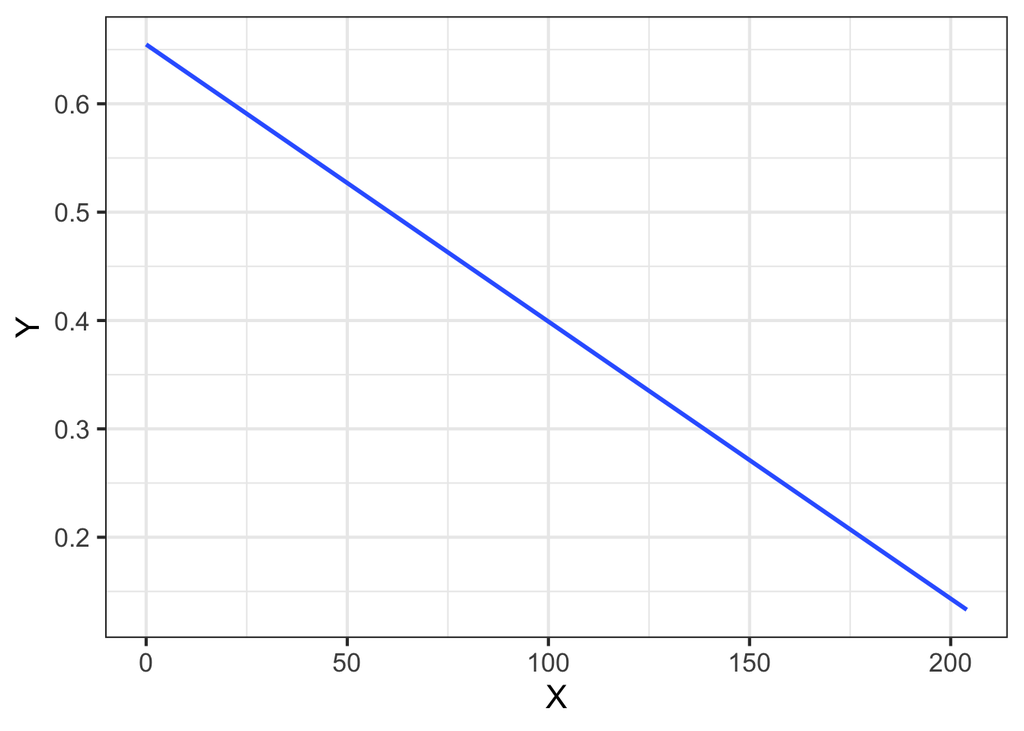

Model 2:
$$Y = \beta_0 + \beta_1X +
\beta_2Z + \beta_3X:Z + \epsilon$$

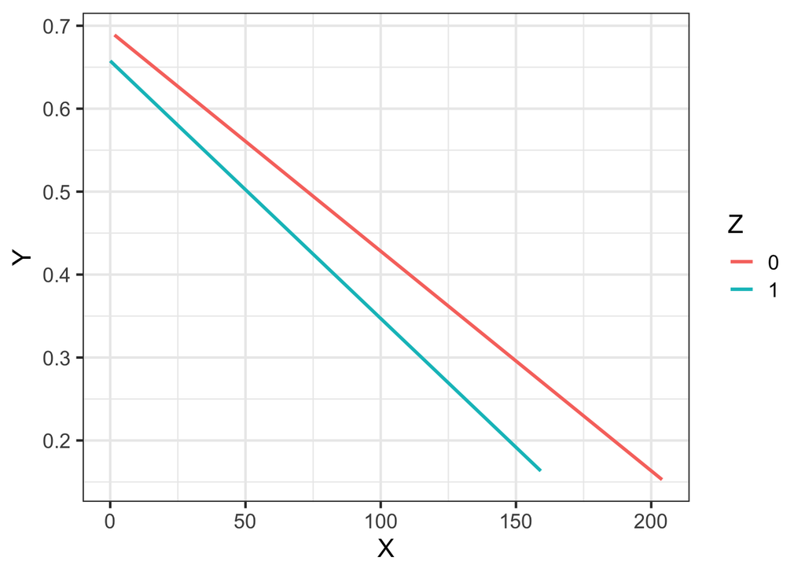

Hopefully, after this lab, you’ll figure out how to use OLS regression to help you find out the intercept and slope for the best fit line of Z = 0 as well as the intercept and slope for the best fit line of Z = 1. Imagine Z = 0 vs Z = 1 is the condition of control vs treatment, how helpful this skill will be to your understanding of the effect of an intervention.

Making sense? Let’s dive into research questions and analyses.

## Key variables

We conducted some data management on the original DIBELS data and currently we have these following variables:

our outcome variable Y (continous, required by OLS)

- score: ORF score (school-by-grade-by-wave level)

our predictor variable X (continous for this lab, check the lecture code for categorical predictor)

- frpl: proportion (school-by-grade level) of students receiving free or reduced price school lunch

our theoretical third variable Z (categorical or continous) that may change the Y-X relationship

- post: coded one for school year 2020-21 and zero for school year 2019-20
- grade: coded 1-5 for 1-5 graders
- enrollment: test enrollment (school level)

Descriptives of continuous variables:

```r
df <- df %>%
  select(-wave)

datasummary_skim(df)
```

Unique (#)

Missing (%)

Mean

SD

Min

Median

Max

enrollment

592

0

337.0

170.0

25.0

326.0

1014.0

[figure not shown]

frpl

1299

0

0.5

0.3

0.0

0.5

1.0

[figure not shown]

score

19469

0

72.9

38.1

0.0

74.4

204.0

[figure not shown]

Descriptives of categorical variables:

```r
datasummary_skim(df, type = "categorical")
```

|  |  | N | % |
| --- | --- | --- | --- |
| grade | 1 | 5736 | 26.6 |
|  | 2 | 5448 | 25.2 |
|  | 3 | 4024 | 18.6 |
|  | 4 | 3324 | 15.4 |
|  | 5 | 3052 | 14.1 |
| post | 0 | 10792 | 50.0 |
|  | 1 | 10792 | 50.0 |

## Research questions

Q1. How did students’ Oral Reading Fluency (ORF) trajectories differ pre- and post-pandemic-onset?

Q2. To what extent did differences in students’ ORF trajectories pre- and post-pandemic-onset differ by the proportion of students receiving free- or reduced-price lunch (FRPL) in their schools?

Q3. To what extent did differences in students’ ORF trajectories pre- and post-pandemic-onset differ by grade level?

Q4. To what extent do students’ average ORF scores differ by the rate of FRPL-receipt and enrollment in their schools?

## Data analysis

We use OLS regression to estimate four linear models in the following.

```r
fit1 <- lm(score ~ post, df)
fit2 <- lm(score ~ post*frpl, df)
fit3 <- lm(score ~ post*grade, df)
fit4 <- lm(score ~ frpl*enrollment, df)
```

Q1 How did students’ Oral Reading Fluency (ORF) trajectories differ pre- and post-pandemic-onset?

$$SCORE = \beta_0 + \beta_1POST +
\epsilon$$

```r
modelsummary(fit1,
             stars = TRUE,
             gof_omit = "Adj.|Log.Lik.|AIC|BIC")
```

|  | Model 1 |
| --- | --- |
| (Intercept) | 75.125*** |
|  | (0.367) |
| post1 | −4.450*** |
|  | (0.518) |
| Num.Obs. | 21584 |
| R2 | 0.003 |
| F | 73.686 |
| RMSE | 38.08 |

+ p < 0.1, * p < 0.05, ** p < 0.01, *** p < 0.001

Compared to pre-pandemic, the average score was 4.450 lower (p < 0.001) post pandemic.

Q2. To what extent did differences in students’ ORF trajectories pre- and post-pandemic-onset differ by the proportion of students receiving free- or reduced-price lunch (FRPL) in their schools?

$$SCORE = \beta_0 + \beta_1POST +
\beta_2FRPL + \beta_3POST:FRPL + \epsilon$$

```r
modelsummary(fit2,
             stars = TRUE,
             gof_omit = "Adj.|Log.Lik.|AIC|BIC")
```

|  | Model 1 |
| --- | --- |
| (Intercept) | 92.548*** |
|  | (0.623) |
| post1 | −4.531*** |
|  | (0.880) |
| frpl | −37.201*** |
|  | (1.101) |
| post1 × frpl | 0.173 |
|  | (1.558) |
| Num.Obs. | 21584 |
| R2 | 0.098 |
| F | 784.267 |
| RMSE | 36.22 |

+ p < 0.1, * p < 0.05, ** p < 0.01, *** p < 0.001

In schools where no student receives free/reduced lunch (frpl = 0 or 0%),

- intercept: 92.548, is the pre-pandemic average score
- slope: −4.531, is the change in score after pandemic, compared to pre-pandemic

Careful - in schools where all students receives free/reduced lunch (frpl = 1 or 100%) (hint: plug frpl = 1 into your model),

- intercept: 92.548 - 37.201 = 55.347, is the pre-pandemic average score
- slope: -4.531 + 0.173 = -4.358, is the change in score after pandemic, compared to pre-pandemic

Taking together, what is the change in slope (i.e., change in score from pre to post-pandemic) that is related to one unit change in the proportion of student receiving free/reduced lunch? is it statistically significant? What is your answer to Q2?

The change in slope is (-4.358) - (-4.531) = 0.173. It is identical to the value of $\beta_3$. Based on an alpha threshold of 0.05, it is not statistically significant. The differences in students’ ORF trajectories pre- and post-pandemic-onset did not change by the proportion of students receiving free- or reduced-price lunch (FRPL) in their schools.

Q3. To what extent did differences in students’ ORF trajectories pre- and post-pandemic-onset differ by grade level?

$$SCORE = \beta_0 + \beta_1POST +
\beta_2GRADE + \beta_3POST:GRADE + \epsilon$$

```r
modelsummary(fit3,
             stars = TRUE,
             gof_omit = "Adj.|Log.Lik.|AIC|BIC")
```

|  | Model 1 |
| --- | --- |
| (Intercept) | 29.249*** |
|  | (0.392) |
| post1 | −3.686*** |
|  | (0.555) |
| grade2 | 40.186*** |
|  | (0.562) |
| grade3 | 60.484*** |
|  | (0.611) |
| grade4 | 82.668*** |
|  | (0.648) |
| grade5 | 82.919*** |
|  | (0.666) |
| post1 × grade2 | −2.398** |
|  | (0.795) |
| post1 × grade3 | −0.094 |
|  | (0.864) |
| post1 × grade4 | −0.988 |
|  | (0.916) |
| post1 × grade5 | 0.083 |
|  | (0.942) |
| Num.Obs. | 21584 |
| R2 | 0.697 |
| F | 5501.903 |
| RMSE | 21.01 |

+ p < 0.1, * p < 0.05, ** p < 0.01, *** p < 0.001

For grade 1 students,

- intercept: 29.249, is the pre-pandemic average score
- slope: -3.686, is the change in score after pandemic, compared to pre-pandemic

Careful - for grade 2 students (hint: plug these into your model, grade2 = 1, grade3 = 0, grade4 = 0, grade5 = 0. [How to? CHECK THE LECTURE](https://daviddliebowitz.github.io/EDUC643_23W/slides/EDUC643_13_interactions.html#30)),

- intercept: 29.249 + 40.186 = 69.435, is the pre-pandemic average score
- slope: (-3.686) + (-2.398) = -6.084, is the change in score after pandemic, compared to pre-pandemic

Careful - for grade 3 students,

- intercept: 29.249 + 60.484 = 89.733, is the pre-pandemic average score
- slope: (-3.686) + (-0.094) = -3.78, is the change in score after pandemic, compared to pre-pandemic

Careful - for grade 4 students,

- intercept: 29.249 + 82.668 = 111.917, is the pre-pandemic average score
- slope: (-3.686) + (-0.988) = -4.674, is the change in score after pandemic, compared to pre-pandemic

Careful - for grade 5 students,

- intercept: 29.249 + 82.919 = 112.168, is the pre-pandemic average score
- slope: (-3.686) + 0.083 = -3.603, is the change in score after pandemic, compared to pre-pandemic

Taking together, what is the difference in slope (i.e., difference in score from pre to post-pandemic) between grade 1 and grade 2? what is the substantive meaning of this number? is it statistically significant? is it one of the answers to Q3? What is your full answer to Q3?

The difference in slope between grade 1 and 2 was the coefficient on post1 × grade2, which was −2.398. It means that, compared to grade 1 students, the difference in students’ ORF trajectories pre- and post-pandemic-onset was 2.398 smaller for grade 2 students. It was statistically significant. It is one of the answers to Q3.

To answer Q3 further, we just need to look at the coefficients of “post1 × grade3”, “post1 × grade4”, and “post1 × grade5”, and we notice that for grades 3-5, the difference in students’ ORF trajectories pre- and post-pandemic-onset did not significantly differ compared to grade 1.

Q4. To what extent do students’ average ORF scores differ by the rate of FRPL-receipt and enrollment in their schools?

$$SCORE = \beta_0 + \beta_1FRPL +
\beta_2ENROLLMENT + \beta_3FRPL:ENROLLMENT + \epsilon$$

```r
modelsummary(fit4,
             stars = TRUE,
             gof_omit = "Adj.|Log.Lik.|AIC|BIC")
```

|  | Model 1 |
| --- | --- |
| (Intercept) | 81.126*** |
|  | (1.032) |
| frpl | −39.378*** |
|  | (1.673) |
| enrollment | 0.025*** |
|  | (0.003) |
| frpl × enrollment | 0.013** |
|  | (0.005) |
| Num.Obs. | 21584 |
| R2 | 0.114 |
| F | 925.685 |
| RMSE | 35.90 |

+ p < 0.1, * p < 0.05, ** p < 0.01, *** p < 0.001

Taking together, what is the difference in slope (i.e., difference in score from pre to post-pandemic) for schools with frpl = 0 vs schools with frpl = 1? what is the substantive meaning of this number? is it statistically significant? is it the answer to Q4?

The difference in slope from schools where no student receives free/reduced lunch to schools where all students receives free/reduced lunch was 0.013. It was statistically significant. It means that, on average, one student enrollment at school is correlated with 0.013 (p < 0.01) increase in the relationship between students’ average ORF scores and the rate of FRPL-receipt - 100% increase in the rate of FRPL-receipt is related to 39.378 (p < 0.001) decrease in score.